# Medical Data Cleaning Pipeline

A reproducible R Markdown workflow for cleaning clinical data, handling biologically impossible values, and producing publication-ready tables and figures.

Eugene Mofeoluwa

October 24, 2026

[figure not shown]

# 1. Overview

This report demonstrates a reproducible pipeline for cleaning clinical data before statistical analysis. Using the **Pima Indians Diabetes** dataset, I show how to:

**Why this matters:** most real-world clinical datasets contain coded missing values (zeros, 999, -1) that silently corrupt analyses if not detected. This pipeline catches them and documents every decision.

# 2. Setup

```r
library(tidyverse)   # data manipulation and plotting
library(janitor)     # cleaning helpers
library(skimr)       # rich descriptive summaries
library(naniar)      # missing-data visualization
library(gtsummary)   # publication-ready tables
library(here)        # reproducible file paths
```

```r
# Define directories relative to project root
dir_raw     <- here("data", "raw")
dir_cleaned <- here("data", "cleaned")
dir_figures <- here("figures")
dir_output  <- here("output")

# Create output directories if they don't exist
walk(c(dir_cleaned, dir_figures, dir_output),
     ~ dir.create(.x, showWarnings = FALSE, recursive = TRUE))
```

# 3. Load the raw data

The dataset contains 768 observations of 8 clinical predictors plus a binary outcome (`Outcome`: 1 = diabetes, 0 = no diabetes).

```r
# Define the URL and the destination file path
url <- "https://raw.githubusercontent.com/jbrownlee/Datasets/master/pima-indians-diabetes.data.csv"
dest_file <- here("data", "raw", "pima_diabetes.csv")

# Download the file if it doesn't already exist
if (!file.exists(dest_file)) {
  download.file(url, dest_file, mode = "wb")
}

# Load the data to verify it's the correct version
diabetes_raw <- read_csv(dest_file, col_names = FALSE)

# Check for the impossible zeros (the values should match these)
# Note: This CSV does not have column headers, so we use column positions.
sum(diabetes_raw$X2 == 0) # Glucose: should be 5
```

```
## [1] 5
```

```r
sum(diabetes_raw$X6 == 0) # BMI: should be 11
```

```
## [1] 11
```

```r
sum(diabetes_raw$X5 == 0) # Insulin: should be 374
```

```
## [1] 374
```

```r
# Add the original column names
colnames(diabetes_raw) <- c(
  "Pregnancies",
  "Glucose",
  "BloodPressure",
  "SkinThickness",
  "Insulin",
  "BMI",
  "DiabetesPedigreeFunction",
  "Age",
  "Outcome"
)
```

```r
glimpse(diabetes_raw)
```

```
## Rows: 768
## Columns: 9
## $ Pregnancies              <dbl> 6, 1, 8, 1, 0, 5, 3, 10, 2, 8, 4, 10, 10, 1, …
## $ Glucose                  <dbl> 148, 85, 183, 89, 137, 116, 78, 115, 197, 125…
## $ BloodPressure            <dbl> 72, 66, 64, 66, 40, 74, 50, 0, 70, 96, 92, 74…
## $ SkinThickness            <dbl> 35, 29, 0, 23, 35, 0, 32, 0, 45, 0, 0, 0, 0, …
## $ Insulin                  <dbl> 0, 0, 0, 94, 168, 0, 88, 0, 543, 0, 0, 0, 0, …
## $ BMI                      <dbl> 33.6, 26.6, 23.3, 28.1, 43.1, 25.6, 31.0, 35.…
## $ DiabetesPedigreeFunction <dbl> 0.627, 0.351, 0.672, 0.167, 2.288, 0.201, 0.2…
## $ Age                      <dbl> 50, 31, 32, 21, 33, 30, 26, 29, 53, 54, 30, 3…
## $ Outcome                  <dbl> 1, 0, 1, 0, 1, 0, 1, 0, 1, 1, 0, 1, 0, 1, 1, …
```

We have 768 rows and 9 columns, all numeric or integer. No `NA` values are visible yet — which is exactly the trap we investigate next.

# 4. First inspection

```r
skim(diabetes_raw)
```

Data summary

| Name | diabetes_raw |
| --- | --- |
| Number of rows | 768 |
| Number of columns | 9 |
| _______________________ |  |
| Column type frequency: |  |
| numeric | 9 |
| ________________________ |  |
| Group variables | None |

**Variable type: numeric**

| skim_variable | n_missing | complete_rate | mean | sd | p0 | p25 | p50 | p75 | p100 | hist |
| --- | --- | --- | --- | --- | --- | --- | --- | --- | --- | --- |
| Pregnancies | 0 | 1 | 3.85 | 3.37 | 0.00 | 1.00 | 3.00 | 6.00 | 17.00 | ▇▃▂▁▁ |
| Glucose | 0 | 1 | 120.89 | 31.97 | 0.00 | 99.00 | 117.00 | 140.25 | 199.00 | ▁▁▇▆▂ |
| BloodPressure | 0 | 1 | 69.11 | 19.36 | 0.00 | 62.00 | 72.00 | 80.00 | 122.00 | ▁▁▇▇▁ |
| SkinThickness | 0 | 1 | 20.54 | 15.95 | 0.00 | 0.00 | 23.00 | 32.00 | 99.00 | ▇▇▂▁▁ |
| Insulin | 0 | 1 | 79.80 | 115.24 | 0.00 | 0.00 | 30.50 | 127.25 | 846.00 | ▇▁▁▁▁ |
| BMI | 0 | 1 | 31.99 | 7.88 | 0.00 | 27.30 | 32.00 | 36.60 | 67.10 | ▁▃▇▂▁ |
| DiabetesPedigreeFunction | 0 | 1 | 0.47 | 0.33 | 0.08 | 0.24 | 0.37 | 0.63 | 2.42 | ▇▃▁▁▁ |
| Age | 0 | 1 | 33.24 | 11.76 | 21.00 | 24.00 | 29.00 | 41.00 | 81.00 | ▇▃▁▁▁ |
| Outcome | 0 | 1 | 0.35 | 0.48 | 0.00 | 0.00 | 0.00 | 1.00 | 1.00 | ▇▁▁▁▅ |

**What to notice:**

- `Insulin` and `SkinThickness` have very wide ranges and suspicious lows.
- Several variables have a **minimum of 0**. In a living human, glucose, blood pressure, BMI, insulin, and skin thickness cannot be zero. These zeros are **impossible values**, and in this dataset they function as missing-data codes.

# 5. Identify impossible zeros

The following variables cannot biologically be zero:

| Variable | Meaning | Zero is impossible because |
| --- | --- | --- |
| Glucose | Plasma glucose (mg/dL) | Fatal at 0 |
| BloodPressure | Diastolic BP (mm Hg) | Fatal at 0 |
| SkinThickness | Triceps skinfold (mm) | Not physically possible |
| Insulin | Serum insulin (mu U/mL) | Not compatible with life |
| BMI | Body mass index | Not physically possible |

```r
vars_with_impossible_zeros <- c(
  "Glucose", "BloodPressure", "SkinThickness", "Insulin", "BMI"
)

zero_summary <- diabetes_raw %>%
  summarise(across(all_of(vars_with_impossible_zeros),
                   ~ sum(.x == 0, na.rm = TRUE))) %>%
  pivot_longer(everything(),
               names_to  = "variable",
               values_to = "n_zeros") %>%
  mutate(pct_zeros = round(100 * n_zeros / nrow(diabetes_raw), 1))

zero_summary
```

| variable | n_zeros | pct_zeros |
| --- | --- | --- |
| Glucose | 5 | 0.7 |
| BloodPressure | 35 | 4.6 |
| SkinThickness | 227 | 29.6 |
| Insulin | 374 | 48.7 |
| BMI | 11 | 1.4 |

`Insulin` is the worst offender — 48.7% of its values are zeros. `SkinThickness` follows at 29.6%.

We now recode these zeros to `NA` so R treats them as genuinely missing.

# 6. Recode impossible zeros to NA

```r
diabetes_clean <- diabetes_raw %>%
  mutate(across(all_of(vars_with_impossible_zeros),
                ~ na_if(.x, 0)))
```

```r
diabetes_clean %>%
  summarise(across(all_of(vars_with_impossible_zeros),
                   ~ sum(is.na(.x)))) %>%
  pivot_longer(everything(),
               names_to  = "variable",
               values_to = "n_missing")
```

| variable | n_missing |
| --- | --- |
| Glucose | 5 |
| BloodPressure | 35 |
| SkinThickness | 227 |
| Insulin | 374 |
| BMI | 11 |

The missing counts now match the zero counts from Section 5, confirming the recode worked.

# 7. Visualize missingness

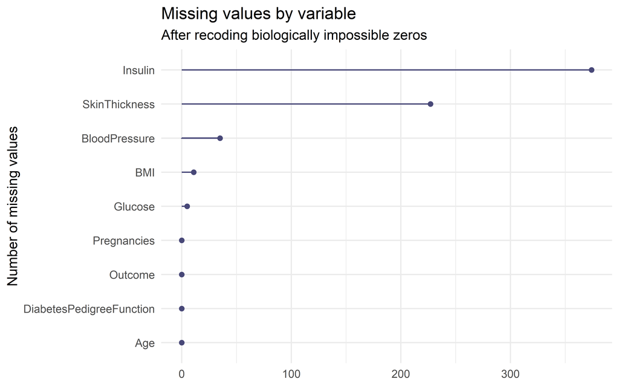

```r
gg_miss_var(diabetes_clean) +
  labs(title = "Missing values by variable",
       subtitle = "After recoding biologically impossible zeros",
       x = "Number of missing values",
       y = NULL) +
  theme_minimal(base_size = 13)
```

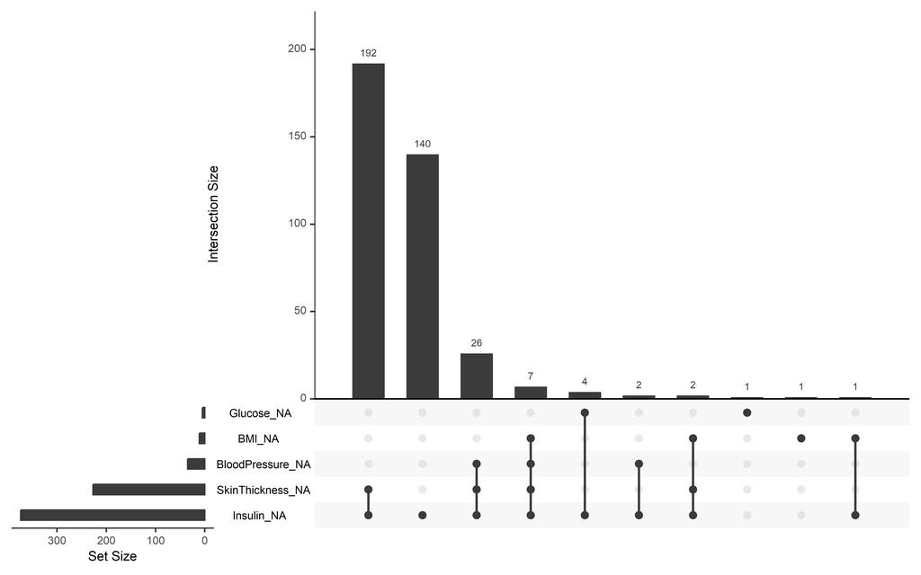

```r
gg_miss_upset(diabetes_clean,
              nsets = length(vars_with_impossible_zeros))
```

# 8. Handle missing data — two strategies

There is no universally correct answer. What matters is that the choice is **documented and defensible**. I compare two standard approaches.

## 8.1 Complete-case analysis

Rows with any missing value are removed.

```r
diabetes_complete <- diabetes_clean %>%
  drop_na()

n_complete <- nrow(diabetes_complete)
n_raw      <- nrow(diabetes_clean)
```

This retains **392** of 768 rows (51%).

**Pros:** Simple, no assumptions, unbiased if data are MCAR. **Cons:** Loses 376 rows, reduces statistical power.

## 8.2 Median imputation

Missing values are replaced with the column median.

```r
diabetes_imputed <- diabetes_clean %>%
  mutate(across(all_of(vars_with_impossible_zeros),
                ~ ifelse(is.na(.x), median(.x, na.rm = TRUE), .x)))
```

**Pros:** Retains all rows. **Cons:** Shrinks variance, distorts distributions, underestimates uncertainty.

**Recommendation for this dataset:** complete-case analysis, because `Insulin` is missing in nearly half the rows and imputing it would create more bias than it removes. In a real project I would discuss this with the client and consider multiple imputation (`mice`) if the missingness were more moderate.

# 9. Descriptive statistics

```r
diabetes_complete %>%
  select(-Outcome) %>%
  skim() %>%
  print()
```

```
## ── Data Summary ────────────────────────
##                            Values
## Name                       Piped data
## Number of rows             392
## Number of columns          8
## _______________________
## Column type frequency:
##   numeric                  8
## ________________________
## Group variables            None
##
## ── Variable type: numeric ──────────────────────────────────────────────────────
##   skim_variable            n_missing complete_rate    mean      sd     p0    p25
## 1 Pregnancies                      0             1   3.30    3.21   0      1
## 2 Glucose                          0             1 123.     30.9   56     99
## 3 BloodPressure                    0             1  70.7    12.5   24     62
## 4 SkinThickness                    0             1  29.1    10.5    7     21
## 5 Insulin                          0             1 156.    119.    14     76.8
## 6 BMI                              0             1  33.1     7.03  18.2   28.4
## 7 DiabetesPedigreeFunction         0             1   0.523   0.345  0.085  0.270
## 8 Age                              0             1  30.9    10.2   21     23
##       p50     p75   p100 hist
## 1   2       5      17    ▇▂▂▁▁
## 2 119     143     198    ▂▇▇▃▂
## 3  70      78     110    ▁▂▇▆▁
## 4  29      37      63    ▅▇▇▃▁
## 5 126.    190     846    ▇▂▁▁▁
## 6  33.2    37.1    67.1  ▃▇▃▁▁
## 7   0.450   0.687   2.42 ▇▃▁▁▁
## 8  27      36      81    ▇▂▁▁▁
```

# 10. Table 1 — characteristics by outcome

```r
table1 <- diabetes_complete %>%
  mutate(Outcome = factor(Outcome,
                          levels = c(0, 1),
                          labels = c("No Diabetes", "Diabetes"))) %>%
  tbl_summary(
    by = Outcome,
    statistic = list(
      all_continuous()  ~ "{median} ({p25}, {p75})",
      all_categorical() ~ "{n} ({p}%)"
    ),
    digits = all_continuous() ~ 1,
    label = list(
      Pregnancies              ~ "Number of pregnancies",
      Glucose                  ~ "Plasma glucose (mg/dL)",
      BloodPressure            ~ "Diastolic blood pressure (mm Hg)",
      SkinThickness            ~ "Triceps skinfold (mm)",
      Insulin                  ~ "Serum insulin (mu U/mL)",
      BMI                      ~ "Body mass index",
      DiabetesPedigreeFunction ~ "Diabetes pedigree function",
      Age                      ~ "Age (years)"
    )
  ) %>%
  add_p() %>%
  add_n() %>%
  bold_labels() %>%
  modify_header(label = "**Characteristic**")

table1
```

| **Characteristic** | **N** | **No Diabetes** N = 262<sup>1</sup> | **Diabetes** N = 130<sup>1</sup> | **p-value**<sup>2</sup> |
| --- | --- | --- | --- | --- |
| Number of pregnancies | 392 | 2.0 (1.0, 4.0) | 3.0 (1.0, 7.0) | <0.001 |
| Plasma glucose (mg/dL) | 392 | 107.5 (94.0, 126.0) | 144.5 (124.0, 172.0) | <0.001 |
| Diastolic blood pressure (mm Hg) | 392 | 70.0 (60.0, 76.0) | 74.0 (66.0, 82.0) | <0.001 |
| Triceps skinfold (mm) | 392 | 27.0 (18.0, 34.0) | 33.0 (26.0, 40.0) | <0.001 |
| Serum insulin (mu U/mL) | 392 | 105.0 (66.0, 165.0) | 169.5 (127.0, 240.0) | <0.001 |
| Body mass index | 392 | 31.3 (26.1, 36.1) | 34.6 (31.6, 38.4) | <0.001 |
| Diabetes pedigree function | 392 | 0.4 (0.3, 0.6) | 0.5 (0.3, 0.8) | <0.001 |
| Age (years) | 392 | 25.0 (22.0, 30.0) | 33.0 (27.0, 43.0) | <0.001 |

<sup>1</sup> Median (Q1, Q3)  
<sup>2</sup> Wilcoxon rank sum test

# 11. Publication-ready figure

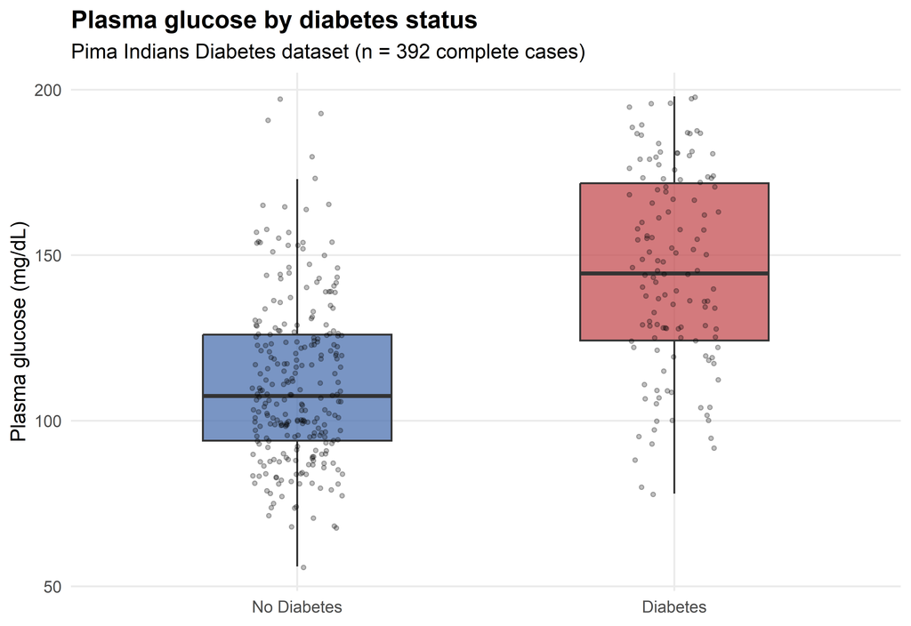

```r
fig_glucose <- diabetes_complete %>%
  mutate(Outcome = factor(Outcome,
                          levels = c(0, 1),
                          labels = c("No Diabetes", "Diabetes"))) %>%
  ggplot(aes(x = Outcome, y = Glucose, fill = Outcome)) +
  geom_boxplot(alpha = 0.75, outlier.shape = NA, width = 0.5) +
  geom_jitter(width = 0.12, alpha = 0.25, size = 1) +
  scale_fill_manual(values = c("#4C72B0", "#C44E52")) +
  labs(
    title    = "Plasma glucose by diabetes status",
    subtitle = paste0("Pima Indians Diabetes dataset (n = ",
                      n_complete, " complete cases)"),
    x        = NULL,
    y        = "Plasma glucose (mg/dL)"
  ) +
  theme_minimal(base_size = 13) +
  theme(
    legend.position = "none",
    plot.title      = element_text(face = "bold"),
    panel.grid.minor = element_blank()
  )

fig_glucose
```

# 12. Save the cleaned dataset

```r
write_csv(diabetes_complete,
          file.path(dir_cleaned, "diabetes_complete.csv"))

write_csv(diabetes_imputed,
          file.path(dir_cleaned, "diabetes_imputed.csv"))
```

# 13. Summary of decisions

[output not shown]

**To reproduce this report:**

1. Clone the repository.
2. Open `medical-data-cleaning-pipeline.Rproj` in RStudio.
3. Ensure `data/raw/pima_diabetes.csv` is present.
4. Click **Knit** (or run `rmarkdown::render("report.Rmd")`).

All paths use `here()` so the project works on any machine.

*Prepared by Eugene Oyedemi* *https://www.linkedin.com/in/eugene-oyedemi-343152300?utm_source=share_via&utm_content=profile&utm_medium=member_android* *https://connect.posit.cloud/eugeneoyedemi*